# Irish Water Usage

## Aim of this report

The aim of this report is to investigate the average daily amount of water used per meter in Ireland by month and by county from the period 2015 to 2021.

## Data Source

Data for monthly and County water usage are available from the CSO:

https://www.cso.ie/en/index.html

Downloaded data are available in the ‘data’ directory.

## Results

**Seasonal Variability:** The highest average monthly water usage was recorded in May and June. This seasonal peak in water consumption can be attributed to several factors. In many regions, these months coincide with the arrival of warmer weather, leading to an increase in outdoor activities, such as gardening and outdoor water use. Additionally, people tend to use more water during the summer for recreational purposes, such as filling swimming pools or running lawn sprinklers. This surge in water demand during the warmer months underscores the importance of water resource management and infrastructure planning to meet the needs of the population during peak periods.

## Conclusions

To ensure a sustainable and reliable water supply, several key points should be considered:

Infrastructure Assessment: Water supply infrastructure in counties with high water usage should be closely examined. This includes assessing the capacity of water treatment plants, pipelines, and distribution systems to meet peak demand during the summer months.

Seasonal Considerations: Seasonal patterns of water consumption, with peaks in summer, should be taken into account. Water utilities should develop strategies to address the increased demand during warmer periods, such as optimizing storage capacity and distribution.

# Notebook

## Investigating Monthly Water Usage, 2015 - 2021

```r
library(sf)
```

```r
# look at data types
str(mean_usage)
```

```
'data.frame':   12 obs. of  8 variables:
 $ Month: chr  "Jan" "Feb" "Mar" "Apr" ...
 $ X2015: int  391 388 402 396 389 396 382 382 374 370 ...
 $ X2016: int  354 352 351 354 358 352 350 351 344 353 ...
 $ X2017: int  350 349 354 359 369 363 361 357 359 358 ...
 $ X2018: int  357 375 384 375 382 402 364 352 354 354 ...
 $ X2019: int  355 356 355 355 362 358 364 352 354 348 ...
 $ X2020: int  354 363 381 397 418 394 376 376 374 369 ...
 $ X2021: int  378 379 383 386 383 393 387 371 368 358 ...
```

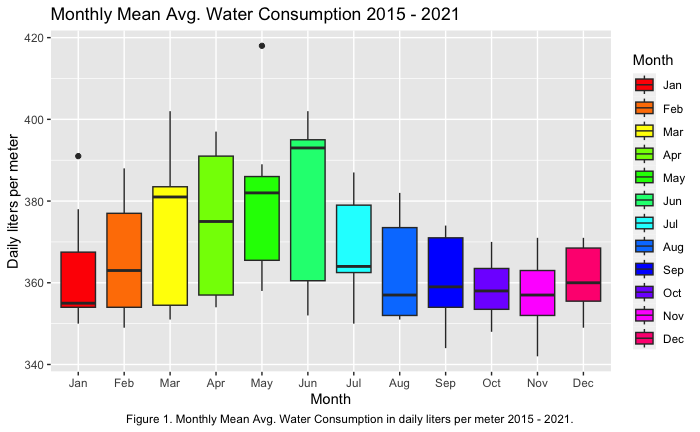

## Investigating Water Usage by County, 2015 - 2021

```r
# List of file paths
file_paths <- c(
  "../data/county_monthly/county_monthly_2015.csv",
  "../data/county_monthly/county_monthly_2016.csv",
  "../data/county_monthly/county_monthly_2017.csv",
  "../data/county_monthly/county_monthly_2018.csv",
  "../data/county_monthly/county_monthly_2019.csv",
  "../data/county_monthly/county_monthly_2020.csv",
  "../data/county_monthly/county_monthly_2021.csv"
)

# Read the CSV files into a list of data frames
list_of_df <- lapply(file_paths, function(file_path) {
  df <- read.csv(file_path, header = TRUE)
  # Ensure all month columns are character
  df <- df %>%
    mutate(across(starts_with("Jan"):ends_with("Dec"), as.character)) %>%
    pivot_longer(cols = -County, names_to = "Month", values_to = "Value")
  return(df)
})

# Add the 'Year' column to each dataframe
years <- 2015:2021
for (i in 1:length(list_of_df)) {
  list_of_df[[i]]$Year <- years[i]
}

# Concatenate all data frames in the list
combined_df <- do.call(rbind, list_of_df)

# Convert the "Value" column to numeric, replacing non-numeric values with NA
combined_df <- combined_df %>%
  mutate(Value = as.numeric(Value))

# Group by 'County' and calculate the average values, ignoring NAs
average_df <- combined_df %>%
  group_by(County) %>%
  summarise(Avg_Value = mean(Value, na.rm = TRUE))

# change Laois to for plotting Laoighis
average_df <- average_df %>%
  mutate(County = ifelse(County == "Laois", "Laoighis", County))

# Print the first few rows of the resulting data frame
head(average_df)
```

```r
# plotting choropleth
county_sf <- st_read("../data/IRL_adm/IRL_adm1.shp")

# merge by county with geospatial dataframe
merged_data <- merge(county_sf, average_df, by.x = "NAME_1", by.y = "County", all.x = TRUE)
```

```r
# Create a choropleth map
tm_shape(merged_data) +
  tm_borders() +  # Add county borders
  tm_fill(col = "Avg_Value", style = "fisher", title = "Daily Water Usage (litres) 2015 - 2021") + tm_legend(outside = TRUE) +
  tm_text("NAME_1", size = 0.6) +
  tm_credits("Figure 2.", fontface = "bold") +
  tm_layout(main.title = "Daily Water Usage by County 2015 - 2021",
            main.title.fontface = "bold")
```

[output not shown]